# Assignment 15: Writing a function - Conditional Statement

*How to do it?*:

- Open the Rmarkdown file of this assignment (link) in Rstudio.
- Right under each **question**, insert a code chunk (you can use the hotkey `Ctrl + Alt + I` to add a code chunk) and code the solution for the question.
- `Knit` the rmarkdown file (hotkey: `Ctrl + Alt + K`) to export an html.
- Publish the html file to your Githiub Page.

*Submission*: Submit the link on Github of the assignment to Canvas

#### NOTICE: Question 7 and 8 are optional.

1. Write a function to calculate the age of a person. Give an example to test your function.
- Input: a number, x, (year born)
- Output: Print out “You are r age”. Where r is the age of the person, i.e. 2020 - x.

```r
fxn1 <- function(birthyear=2021) {
  r <- 2021 - birthyear
  print(paste0('You are ', r, ' years old!'))
}
  fxn1(birthyear = 2000)
```

```
## [1] "You are 21 years old!"
```

```r
  fxn1(birthyear = 1947)
```

```
## [1] "You are 74 years old!"
```

Hint: [Similar Function](https://bryantstats.github.io/math421/gganimate/17_writing_functions_fa21.html#41)

2. Write the following function. Give an example to test your function.
- Input: a number
- Output: print out: “You input an even number!” if the number is event, or “You input an odd number!” otherwise.

```r
evn <- function(x=0) {
    if(x%%2==0)
  {
    print('Your input is even!')
  }
  else
  {
    print('Your input is odd!')
  }

}
  evn(x = 934758)
```

```
## [1] "Your input is even!"
```

```r
  evn(x = 93475)
```

```
## [1] "Your input is odd!"
```

Hint: [Similar Function](https://bryantstats.github.io/math421/gganimate/17_writing_functions_fa21.html#45)

3. Write the following function. Give an example to test your function.
- Input: a numeric vector
- Output:
  - if the input vector has missing values: return the input vector with missing values replaced by mean
  - if the input vector has no missing value: return the same input vector

```r
replaceblanks <- function(x)
{
  if(is.numeric(x))
  {
    library(tidyr)
    y <- replace_na(x,mean(x, na.rm=TRUE))
  }
return(y)
}
numericarray <- as.numeric(c(2,4,5,NA,12,24))
replaceblanks(x = numericarray)
```

```
## [1]  2.0  4.0  5.0  9.4 12.0 24.0
```

Hint: [Similar Function](https://bryantstats.github.io/math421/gganimate/17_writing_functions_fa21.html#49)

4. Write the following function. Give an example to test your function.
- Input: a vector x
- Output: The vector x where the missing values replaced by the mean (if x is numeric) or the mode (if x is non-numeric). If x does not have missing value, return the same vector x.

Hint: Use If-statement to combine the function in Question 3 and [this function](https://bryantstats.github.io/math421/gganimate/17_writing_functions_fa21.html#49)

```r
replaceblanks2 <- function(x)
{
  if(is.numeric(x))
  {
    library(tidyr)
    y <- replace_na(x,mean(x, na.rm=TRUE))
  }
   if(!is.numeric(x))
  {
    # Find the mode of x
    mode_of_x <- names(sort(-table(x)))[1]
    # Replace the missing by the mode
    library(tidyr)
    y <- replace_na(x, mode_of_x)
  }
return(y)
}
numericarray <- as.numeric(c(2,4,5,NA,12,24))
replaceblanks2(x = numericarray)
```

```
## [1]  2.0  4.0  5.0  9.4 12.0 24.0
```

```r
nonnumeric <- c('RI','CT','MA',NA,'NH','RI','RI','MA')
replaceblanks2(x=nonnumeric)
```

```
## [1] "RI" "CT" "MA" "RI" "NH" "RI" "RI" "MA"
```

5. Write the following function. Give examples to test your function.
- Input: A data frame of two variables x and y
- Output:
  - A boxplot of x by y if x is numeric and y is non-numeric
  - A boxplot of y by x if y is numeric and x is non-numeric
  - print out ‘This function cannot visualize your data’ otherwise

Hint:

- [Similar Function](https://bryantstats.github.io/math421/gganimate/17_writing_functions_fa21.html#53)
- You can refer to this slide to plot a boxplot: https://bryantstats.github.io/math421/slides/6_viz.html#36

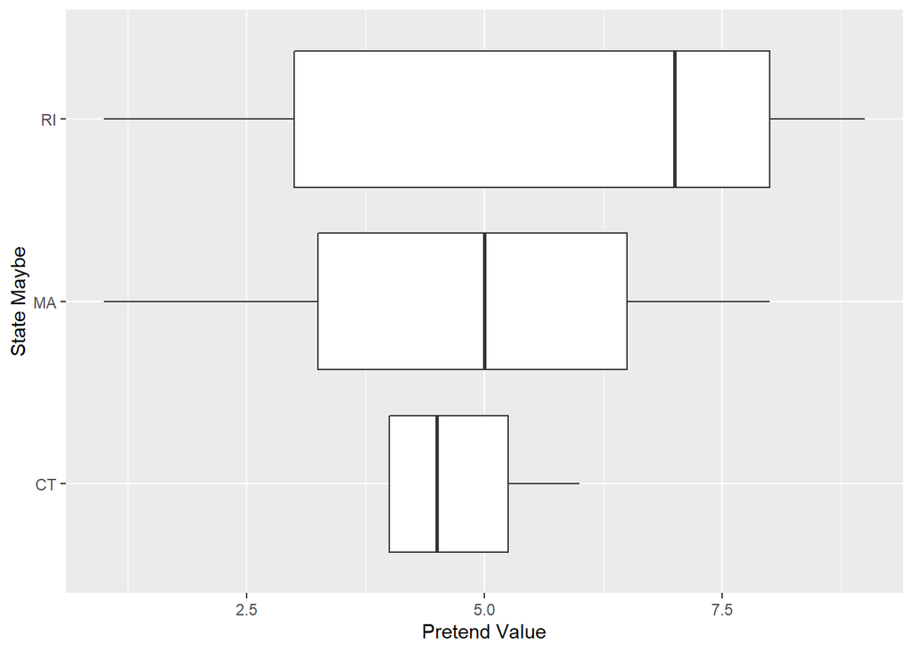

```r
vizzz <- function(d)
{
  library(ggplot2)
  if(is.numeric(d[[2]])|!is.numeric(d[[1]]))
  {
    d %>% ggplot()+geom_boxplot(mapping = aes(x = d[[2]], y = d[[1]]))+ labs(x = names(d)[2], y =names(d)[1])
  }
  else if (is.numeric(d[[1]])|!is.numeric(d[[2]]))
  {
    d %>% ggplot()+
  geom_boxplot(mapping = aes(x = d[[1]], y = d[[2]]))+
      labs(x = names(d)[1], y = names(d)[2])
  }
  else
  {
    print('This function cannot visualize your data.')
  }
}
library(tidyverse)
d <-read_csv("C:/Users/student/Desktop/R 421/testdata.csv")
vizzz(d)
```

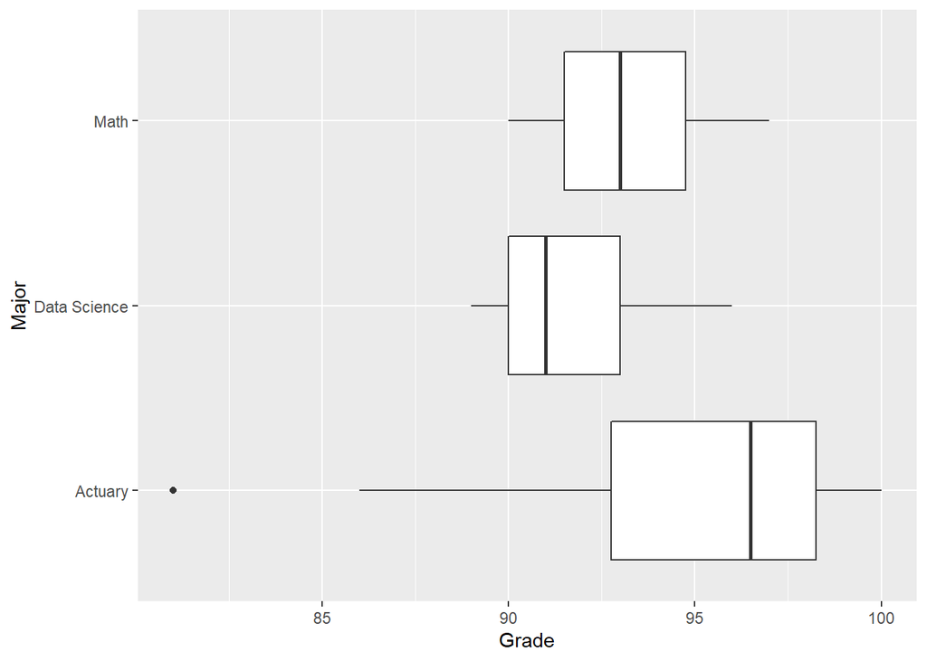

```r
d2 <-read_csv("C:/Users/student/Desktop/R 421/testdata2.csv")
vizzz(d2)
```

```r
#Note: This data is just pretend and is very biased because I am an actuarial major.
```

6. Combine the function in Question 5 and the function in this example ([Link](https://bryantstats.github.io/math421/gganimate/17_writing_functions_fa21.html#53)) to have a function that can plot all possible cases (2 categorical, 2 numeric, 1 numeric and 1 categorical).

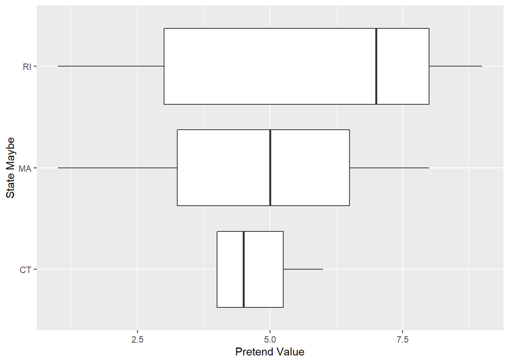

```r
AllViz <- function(d)
{
  library(ggplot2)
  if(is.numeric(d[[2]])&!is.numeric(d[[1]]))
  {
    d %>% ggplot()+geom_boxplot(mapping = aes(x = d[[2]], y = d[[1]]))+ labs(x = names(d)[2], y =names(d)[1])
  }
  else if (is.numeric(d[[1]])&!is.numeric(d[[2]]))
  {
    d %>% ggplot()+
  geom_boxplot(mapping = aes(x = d[[1]], y = d[[2]]))+
      labs(x = names(d)[1], y = names(d)[2])
  }
  else if(is.numeric(d[[1]])& is.numeric(d[[2]]))
  {
    d %>% ggplot(aes(x = d[[1]], y = d[[2]]))+
      geom_point()+
      labs(x = names(d)[1], y = names(d)[2])
  }
  else if (!(is.numeric(d[[1]]))& !(is.numeric(d[[2]])))
  {
    d %>% ggplot(aes(x = d[[1]], fill = d[[2]]))+ geom_bar(position = 'dodge')+ labs(x = names(d)[1], fill = names(d)[2])
  }
  else
  {
    print('This function cannot visualize your data.')
  }
}
library(tidyverse)
d1 <-read_csv("C:/Users/student/Desktop/R 421/testdata.csv")
AllViz(d1)
```

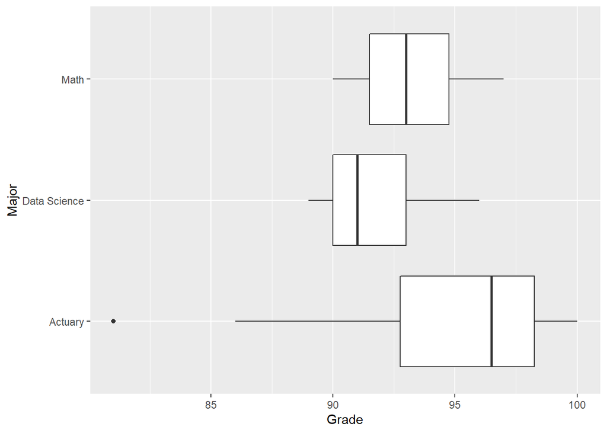

```r
d2 <-read_csv("C:/Users/student/Desktop/R 421/testdata2.csv")
AllViz(d2)
```

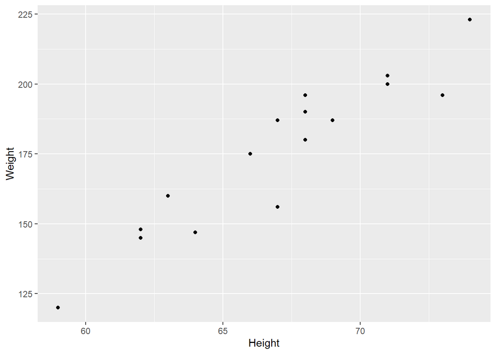

```r
d3 <-read_csv("C:/Users/student/Desktop/R 421/testdata3.csv")
AllViz(d3)
```

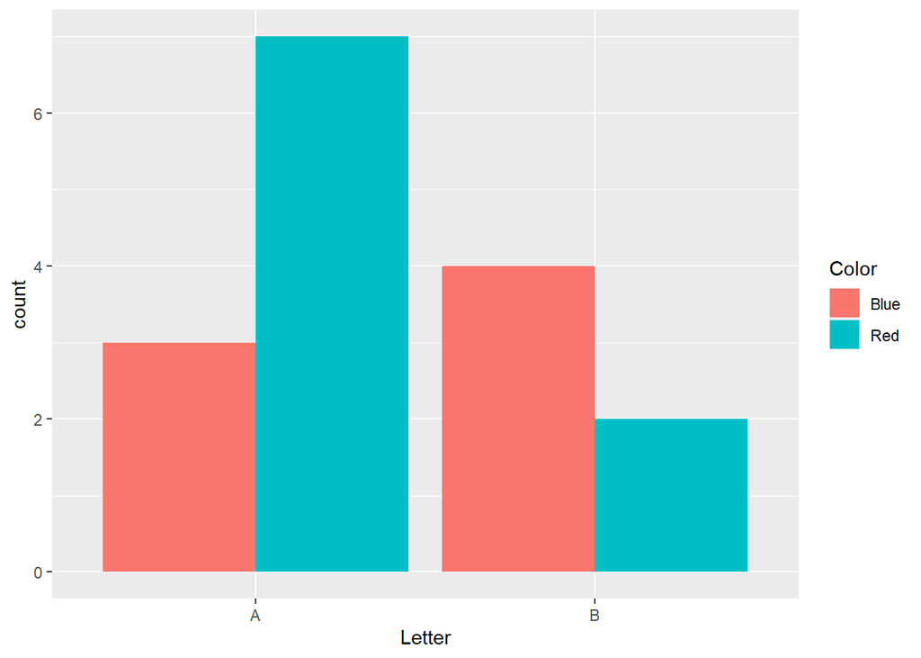

```r
d4 <-read_csv("C:/Users/student/Desktop/R 421/testdata4.csv")
AllViz(d4)
```

#### NOTICE: Question 7 and 8 were optional and skipped.

9. Write the following function. Give examples to test your function.
- Input:
  - a data frame that has a text column
  - the name of the text column in the data
- Output: the word cloud plot of the text column

Sample codes

- [Word Cloud codes](https://bryantstats.github.io/math421/text_mining_sample_codes2.html#2_Word_Cloud)
- [A similar function](https://bryantstats.github.io/math421/gganimate/17_writing_functions_fa21_fa21.html#10)

```r
wcloud<- function(text_df = A, text_column = B) {
library(tidyverse)
library(wordcloud)
library(tidytext)
pal <- brewer.pal(8,"Dark2")
text_df %>%
  unnest_tokens(input = text_column, output = word) %>%
  anti_join(get_stopwords()) %>%
  count(word, sort = TRUE) %>%
  with(wordcloud(word, n, random.order = FALSE, max.words = 50, colors=pal))
}

pal <- brewer.pal(8,"Dark2")
```

```
## Error in brewer.pal(8, "Dark2"): could not find function "brewer.pal"
```

```r
dfword %>%
  unnest_tokens(input = description, output = word) %>%
  anti_join(get_stopwords()) %>%
  count(word, sort = TRUE) %>%
  with(wordcloud(word, n, random.order = FALSE, max.words = 50, colors=pal))
```

```
## Error in unnest_tokens(., input = description, output = word): could not find function "unnest_tokens"
```

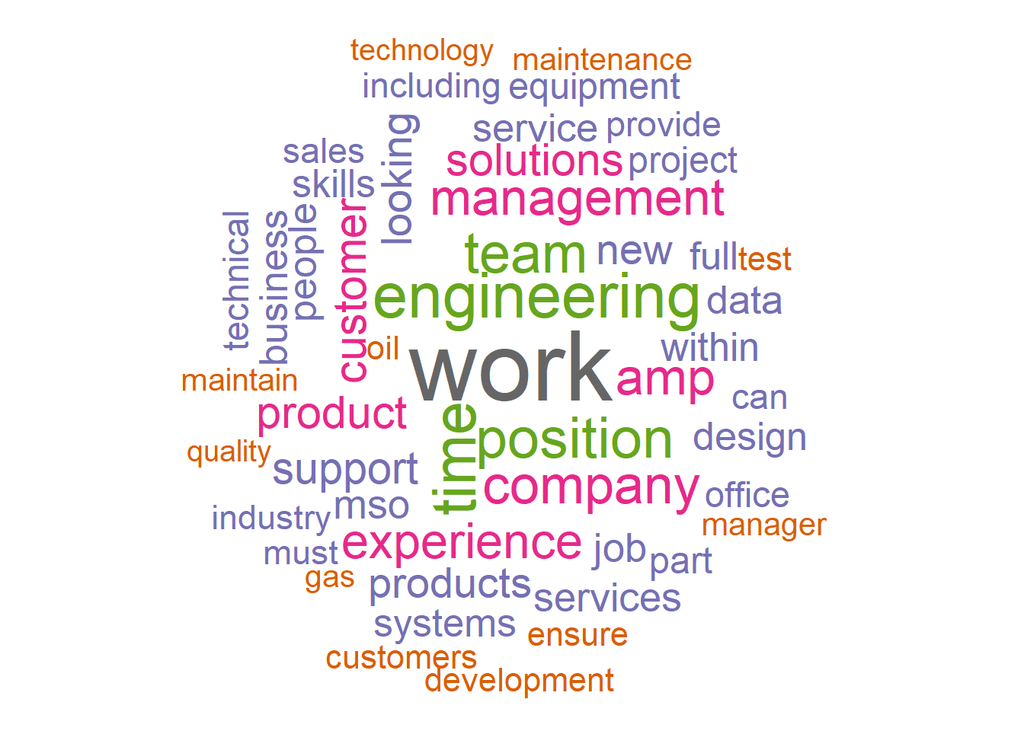

```r
dfword <- read_csv("C:/Users/student/Desktop/R 421/fake_job_postings.csv")
dfword <- head(dfword, 100)
#to make it run quicker

wcloud(text_df = dfword, text_column = 'description')
```